# Analysis on Brazilian elections

Multivariate Linear Regression on data about Brazilian elections

José Benardi de Souza Nunes

10/10/2018

# Introduction

# Data Overview

## Loading Data

```r
eleicoes_data <- readr::read_csv(
  here::here('data/eleicoes_2006_e_2010.csv'),
  progress = FALSE,
  local=readr::locale("br"),
  col_types = cols(
    ano = col_integer(),
    sequencial_candidato = col_character(),
    quantidade_doacoes = col_integer(),
    quantidade_doadores = col_integer(),
    total_receita = col_double(),
    media_receita = col_double(),
    recursos_de_outros_candidatos.comites = col_double(),
    recursos_de_pessoas_fisicas = col_double(),
    recursos_de_pessoas_juridicas = col_double(),
    recursos_proprios = col_double(),
    `recursos_de_partido_politico` = col_double(),
    quantidade_despesas = col_integer(),
    quantidade_fornecedores = col_integer(),
    total_despesa = col_double(),
    media_despesa = col_double(),
    votos = col_integer(),
    .default = col_character()))
```

```r
# Let's put everything in Upper case for uniformity
eleicoes_data %>%
  mutate(nome = toupper(nome),
         sexo = toupper(sexo),
         grau = toupper(grau),
         nome = toupper(nome),
         cargo = toupper(cargo),
         ocupacao = toupper(ocupacao),
         partido = toupper(partido),
         estado_civil = toupper(estado_civil),
         sequencial_candidato = as.numeric(sequencial_candidato)) -> eleicoes_data
# Adding surrogate key to dataframe
eleicoes_data$id <- 1:nrow(eleicoes_data)
eleicoes_data %>%
  glimpse()
```

```
Observations: 7,476
Variables: 25
$ ano                                   <int> 2006, 2006, 2006, 2006, 2006, 2006, 2006, 2006, ...
$ sequencial_candidato                  <dbl> 10001, 10002, 10002, 10002, 10003, 10003, 10003,...
$ nome                                  <chr> "JOSÉ LUIZ NOGUEIRA DE SOUSA", "LOIVA DE OLIVEIR...
$ uf                                    <chr> "AP", "RO", "AP", "MS", "RO", "PI", "MS", "MG", ...
$ partido                               <chr> "PT", "PT", "PT", "PRONA", "PT", "PCO", "PRONA",...
$ quantidade_doacoes                    <int> 6, 13, 17, 6, 48, 6, 14, 2, 5, 2, 68, 13, 61, 24...
$ quantidade_doadores                   <int> 6, 13, 16, 6, 48, 6, 7, 2, 3, 2, 65, 13, 54, 23,...
$ total_receita                         <dbl> 16600.00, 22826.00, 158120.80, 3001.12, 119820.0...
$ media_receita                         <dbl> 2766.67, 1755.85, 9301.22, 500.19, 2496.25, 295....
$ recursos_de_outros_candidatos.comites <dbl> 0.00, 6625.00, 2250.00, 0.00, 0.00, 0.00, 0.00, ...
$ recursos_de_pessoas_fisicas           <dbl> 9000.00, 15000.00, 34150.00, 1150.00, 50878.00, ...
$ recursos_de_pessoas_juridicas         <dbl> 6300.00, 1000.00, 62220.80, 1101.12, 0.00, 0.00,...
$ recursos_proprios                     <dbl> 1300.00, 201.00, 59500.00, 750.00, 68942.00, 177...
$ recursos_de_partido_politico          <dbl> 0, 0, 0, 0, 0, 0, 0, 0, 11570, 0, 0, 0, 0, 3502,...
$ quantidade_despesas                   <int> 14, 24, 123, 8, 133, 9, 17, 332, 51, 10, 68, 52,...
$ quantidade_fornecedores               <int> 14, 23, 108, 8, 120, 9, 10, 278, 33, 10, 67, 49,...
$ total_despesa                         <dbl> 16583.60, 20325.99, 146011.70, 3001.12, 116416.6...
$ media_despesa                         <dbl> 1184.54, 846.92, 1187.09, 375.14, 875.31, 196.80...
$ cargo                                 <chr> "DEPUTADO FEDERAL", "DEPUTADO FEDERAL", "DEPUTAD...
$ sexo                                  <chr> "MASCULINO", "FEMININO", "FEMININO", "MASCULINO"...
$ grau                                  <chr> "ENSINO MÉDIO COMPLETO", "SUPERIOR COMPLETO", "S...
$ estado_civil                          <chr> "CASADO(A)", "SOLTEIRO(A)", "VIÚVO(A)", "CASADO(...
$ ocupacao                              <chr> "VEREADOR", "SERVIDOR PÚBLICO ESTADUAL", "PEDAGO...
$ votos                                 <int> 8579, 2757, 17428, 1193, 29401, 1822, 317, 2591,...
$ id                                    <int> 1, 2, 3, 4, 5, 6, 7, 8, 9, 10, 11, 12, 13, 14, 1...
```

## The variables

```
The response variable is the variable that you are interested in reaching conclusions about.

A predictor variable is a variable used to predict another variable.

Our response variable will be "votos", we want to study how well the predictor variables can help predict its behavior and how they impact in the linear regression.
```

#### Each item corresponds to a candidate, the attributes of each item are as follows:

- **ano** : Year at which the election took place.
- **sequencial_candidato** : Sequential ID to map the candidates
- **nome** : Name of the candidate
- **uf** : Federate state to which the candidate belongs.
- **partido** : Political party to which the candidate belongs.
- **quantidade_doacoes** : Number of donations received during political campaign.
- **quantidade_doadores** : Number of donators that contributed to the candidate’s political campaign.
- **total_receita** : Total revenue.
- **media_receita** : Mean revenue.
- **recursos_de_outros_candidatos.comites** : Revenue coming from other candidate’s committees.
- **recursos_de_pessoas_fisicas** : Revenue coming from individuals.
- **recursos_de_pessoas_juridicas** : Revenue coming from legal entities.
- **recursos_proprios** : Revenue coming from personal resources.
- **recursos_de_partido_politico** : Revenue coming from political party.
- **quantidade_despesas** : Number of expenses.
- **quantidade_fornecedores** : Number of suppliers.
- **total_despesa** : Total expenditure.
- **media_despesa** : Mea expenditure.
- **cargo** : Position.
- **sexo** : Sex.
- **grau** : Level of education.
- **estado_civil** : Marital status.
- **ocupacao** : Candidate’s occupation up to the election.
- **votos** : Number of votes received.

## Data Exploration

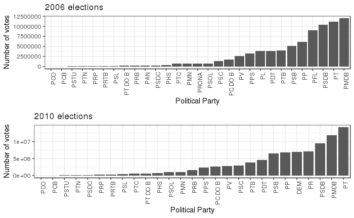

```r
eleicoes_data %>%
  filter(ano == 2006) %>%
  group_by(partido) %>%
  summarize(n = sum(votos)) %>%
  ggplot(aes(reorder(partido,n), n)) +
  geom_bar(stat = "identity") +
  theme(axis.text.x = element_text(angle = 90,
                                   hjust = 1)) +
  labs(x="Political Party",
       title="2006 elections",
       y="Number of votes") -> p1
eleicoes_data %>%
  filter(ano == 2010) %>%
  group_by(partido) %>%
  summarize(n = sum(votos)) %>%
  ggplot(aes(reorder(partido,n), n)) +
  geom_bar(stat = "identity") +
  theme(axis.text.x = element_text(angle = 90,
                                   hjust = 1)) +
  labs(x="Political Party",
       title="2010 elections",
       y="Number of votes") -> p2
grid.arrange(p1, p2, ncol=1)
```

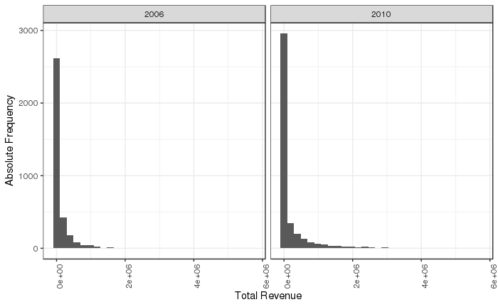

```r
eleicoes_data %>%
  ggplot(aes(total_receita)) +
  geom_histogram(bins = 30) +
  labs(x="Total Revenue",
       y="Absolute Frequency") +
  facet_grid(. ~ ano) +
  theme(axis.text.x = element_text(angle = 90, hjust = 1))
```

- We can see a positive skew where small values are very frequent
- This indicates that for this predictor: $mode < median < mean$

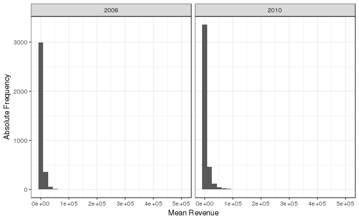

```r
eleicoes_data %>%
  ggplot(aes(media_receita)) +
  geom_histogram(bins = 30) +
  labs(x="Mean Revenue",
       y="Absolute Frequency") +
  facet_grid(. ~ ano)
```

- We can see a positive skew where small values are very frequent
- This indicates that for this predictor: $mode < median < mean$

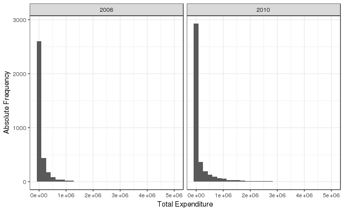

```r
eleicoes_data %>%
  ggplot(aes(total_despesa)) +
  geom_histogram(bins = 30) +
  labs(x="Total Expenditure",
       y="Absolute Frequency") +
  facet_grid(. ~ ano)
```

- We can see a positive skew where small values are very frequent
- This indicates that for this predictor: $mode < median < mean$

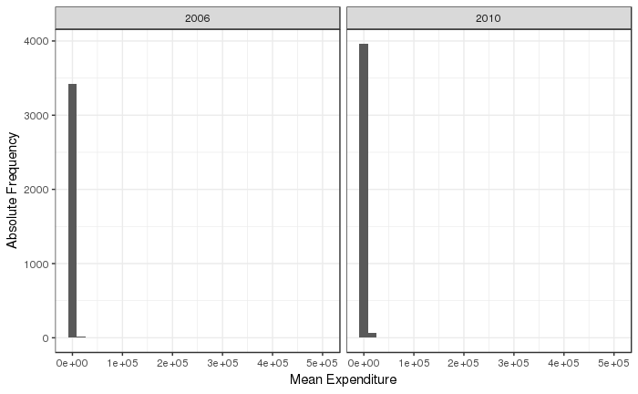

```r
eleicoes_data %>%
  ggplot(aes(media_despesa)) +
  geom_histogram(bins = 30) +
  labs(x="Mean Expenditure",
       y="Absolute Frequency") +
  facet_grid(. ~ ano)
```

- We can see a positive skew where small values are very frequent
- This indicates that for this predictor: $mode < median < mean$

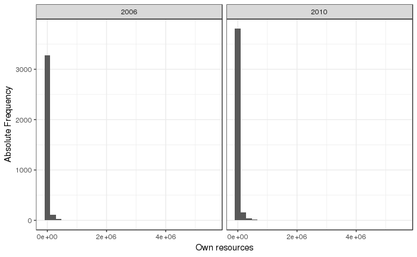

```r
eleicoes_data %>%
  ggplot(aes(recursos_proprios)) +
  geom_histogram(bins = 30) +
  labs(x="Own resources",
       y="Absolute Frequency") +
  facet_grid(. ~ ano)
```

- We can see a positive skew where small values are very frequent
- This indicates that for this predictor: $mode < median < mean$

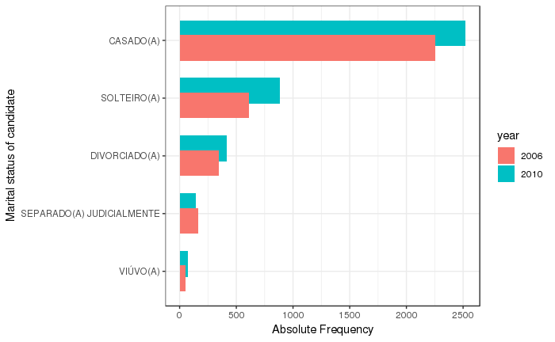

```r
eleicoes_data %>%
  mutate(ano = as.factor(ano)) %>%
  group_by(estado_civil, ano) %>%
  summarize(n = n()) %>%
  ggplot(aes(reorder(estado_civil,n), n,
             fill= ano)) +
  geom_bar(stat = "identity",
           position = position_dodge(width = 0.5)) +
  labs(x="Marital status of candidate",
       y="Absolute Frequency") +
  guides(fill = guide_legend(title = "year")) +
  coord_flip()
```

2010 overall tops 2006 in the number of candidates of each and every marital status with **one exception**:

- We see a decrease of candidates whose marital status is *SEPARADO(A) JUDICIALMENTE* from 2006 to 2010.

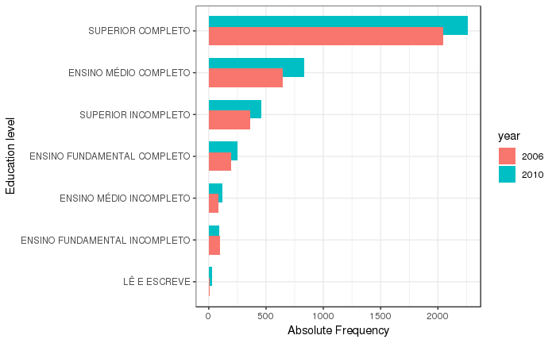

```r
eleicoes_data %>%
  mutate(ano = as.factor(ano)) %>%
  group_by(grau, ano) %>%
  summarize(n = n()) %>%
  ggplot(aes(reorder(grau,n), n,
             fill= ano)) +
  geom_bar(stat = "identity",
           position = position_dodge(width = 0.5)) +
  labs(x="Education level",
       y="Absolute Frequency") +
  guides(fill = guide_legend(title = "year")) +
  coord_flip()
```

2010 overall tops 2006 in the number of candidates of each and every education level with **one exception**:

- The number of candidates with level of education *ENSINO FUNDAMENTAL INCOMPLETO* decreased.

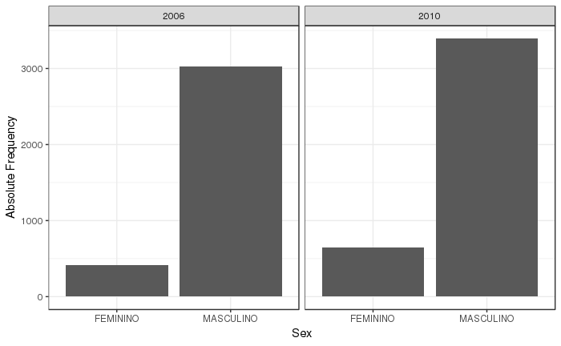

```r
eleicoes_data %>%
  group_by(sexo, ano) %>%
  summarize(n = n()) %>%
  ggplot(aes(reorder(sexo,n), n)) +
  geom_bar(stat = "identity") +
  labs(x="Sex",
       y="Absolute Frequency") +
  facet_grid(. ~ano)
```

- Male predominance is maintained across elections.

## Evaluating *skew* on predictors

##### Let’s take a look at the quantitative predictors of interest.

- **sequencial candidato** has no meaning attached to it so we’ll skip it.

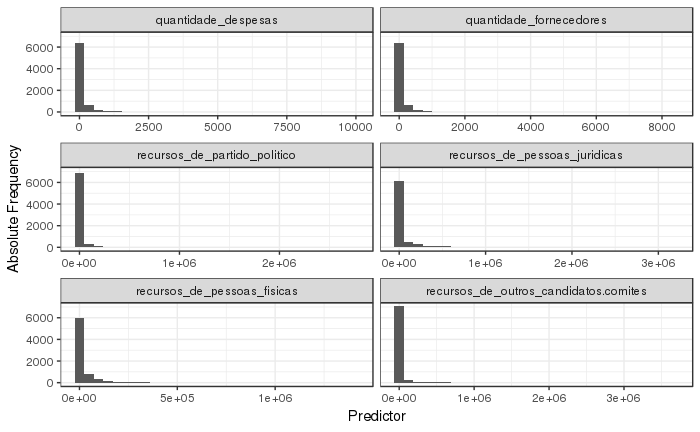

```r
eleicoes_data %>%
  select(id,
         quantidade_despesas,
         quantidade_fornecedores,
         recursos_de_partido_politico,
         recursos_de_pessoas_juridicas,
         recursos_de_pessoas_fisicas,
         recursos_de_outros_candidatos.comites) %>%
  melt(id=c("id"))  %>%
  ggplot(aes(x = value)) +
  geom_histogram(bins = 30) +
  facet_wrap(. ~ variable,
             ncol = 2,
             scales = "free_x")  +
  labs(x="Predictor",y="Absolute Frequency")
```

- We can see a *positive skew* across checked predictors even if different elections are no longer discriminated.

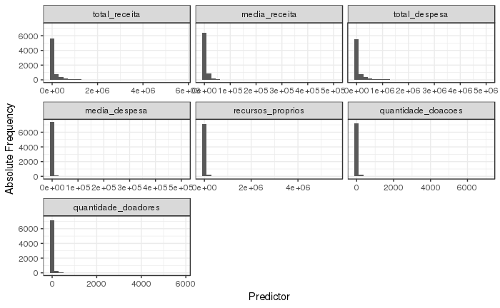

```r
eleicoes_data %>%
  select(id,
         total_receita,
         media_receita,
         total_despesa,
         media_despesa,
         recursos_proprios,
         quantidade_doacoes,
         quantidade_doadores) %>%
  melt(id=c("id"))  %>%
  ggplot(aes(x = value)) +
  geom_histogram(bins = 30) +
  facet_wrap(. ~ variable,
             scales = "free_x") +
  labs(x="Predictor",y="Absolute Frequency")
```

- The overall *positive skew* extends to these variables as well even if different elections are no longer discriminated.

#### Dealing with *positive skew*

The standard method to deal with a *positive skew* is to apply a logarithmic transformation to the affected predictor. However, to apply the aforementioned transformation **the predictor must not contain any 0**.

```r
eleicoes_data %>%
  select(quantidade_doacoes,
         quantidade_doadores,
         total_receita,
         media_receita,
         recursos_de_outros_candidatos.comites,
         recursos_de_pessoas_fisicas,
         recursos_de_pessoas_juridicas,
         recursos_proprios,
         recursos_de_partido_politico,
         quantidade_despesas,
         quantidade_fornecedores,
         total_despesa,
         media_despesa) %>%
  sapply(., function(x) 0 %in% x) %>%
  as.data.frame(row.names = NULL) %>%
  tibble::rownames_to_column() %>%
  set_colnames(c("predictor","contains_zero")) %>%
  arrange(contains_zero)
```

| predictor | contains_zero |
| --- | --- |
| quantidade_doacoes | FALSE |
| quantidade_doadores | FALSE |
| quantidade_despesas | FALSE |
| quantidade_fornecedores | FALSE |
| total_receita | TRUE |
| media_receita | TRUE |
| recursos_de_outros_candidatos.comites | TRUE |
| recursos_de_pessoas_fisicas | TRUE |
| recursos_de_pessoas_juridicas | TRUE |
| recursos_proprios | TRUE |

[output cut: 3 more lines]

- There are four predictors on which we may apply the logarithmic transformation
- We’ll resort to square root transformation for the rest.

```r
# apply logarithmic transformation
eleicoes_data %>%
  mutate(log.quantidade_doacoes = log10(quantidade_doacoes),
         log.quantidade_doadores = log10(quantidade_doadores),
         log.quantidade_despesas = log10(quantidade_despesas),
         log.quantidade_fornecedores = log10(quantidade_fornecedores),
         sqrt.total_receita = sqrt(total_receita),
         sqrt.media_receita = sqrt(media_receita),
         sqrt.total_despesa = sqrt(total_despesa),
         sqrt.media_despesa = sqrt(media_despesa),
         sqrt.recursos_proprios = sqrt(recursos_proprios),
         sqrt.recursos_de_pessoas_juridicas = sqrt(recursos_de_pessoas_juridicas),
         sqrt.recursos_de_partido_politico = sqrt(recursos_de_partido_politico),
         sqrt.recursos_de_outros_candidatos.comites = sqrt(recursos_de_outros_candidatos.comites),
         sqrt.recursos_de_pessoas_fisicas = sqrt(recursos_de_pessoas_fisicas)) -> eleicoes_data
# put all quantitative predictors (of interest) in same scale
eleicoes_data %>%
  mutate_at(.vars = vars(quantidade_doacoes,
                         quantidade_doadores,
                         total_receita,
                         media_receita,
                         sqrt.total_receita,
                         sqrt.media_receita,
                         sqrt.recursos_de_outros_candidatos.comites,
                         sqrt.recursos_de_pessoas_fisicas,
                         sqrt.recursos_de_pessoas_juridicas,
                         sqrt.recursos_proprios,
                         sqrt.recursos_de_partido_politico,
                         sqrt.total_despesa,
                         sqrt.media_despesa,
                         log.quantidade_doacoes,
                         log.quantidade_doadores,
                         log.quantidade_despesas,
                         log.quantidade_fornecedores,
                         sequencial_candidato,
                         recursos_de_outros_candidatos.comites,
                         recursos_de_pessoas_fisicas,
                         recursos_de_pessoas_juridicas,
                         recursos_proprios,
                         recursos_de_partido_politico,
                         quantidade_despesas,
                         quantidade_fornecedores,
                         total_despesa,
                         media_despesa),
             .funs = funs(as.numeric(scale(.)))) -> scaled_data
```

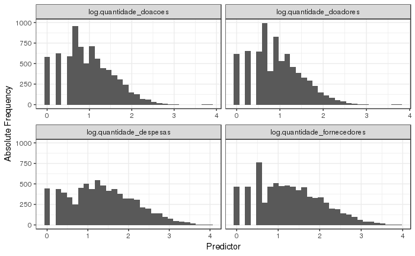

```r
eleicoes_data %>%
  select(id,
         log.quantidade_doacoes,
         log.quantidade_doadores,
         log.quantidade_despesas,
         log.quantidade_fornecedores) %>%
  melt(id=c("id"))  %>%
  ggplot(aes(x = value)) +
  geom_histogram(bins = 30) +
  facet_wrap(. ~ variable,
             scales = "free_x") +
  labs(x="Predictor",y="Absolute Frequency")
```

- We have evidence that the positive skew has been atenuated by the logarithmic transformations.

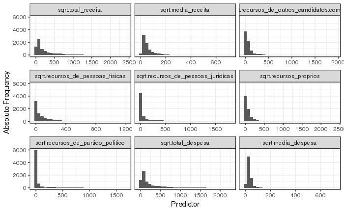

```r
eleicoes_data %>%
  select(id,
         sqrt.total_receita,
         sqrt.media_receita,
         sqrt.recursos_de_outros_candidatos.comites,
         sqrt.recursos_de_pessoas_fisicas,
         sqrt.recursos_de_pessoas_juridicas,
         sqrt.recursos_proprios,
         sqrt.recursos_de_partido_politico,
         sqrt.total_despesa,
         sqrt.media_despesa) %>%
  melt(id=c("id"))  %>%
  ggplot(aes(x = value)) +
  geom_histogram(bins = 30) +
  facet_wrap(. ~ variable,
             scales = "free_x") +
  labs(x="Predictor",y="Absolute Frequency")
```

- We have evidence that the positive skew has been atenuated by the square root transformation.
  - On a side note, the square root transformation seems less eficient than the logarithmic transformation.

## Discern promising predictors

##### We’ll use the correlogram to have an idea on how the predictors interact with each and with the target variable. How the predictors react with the target **votos** is of particular interest.

- Predictors whom have been transformed will be replaced by their enhanced versions.

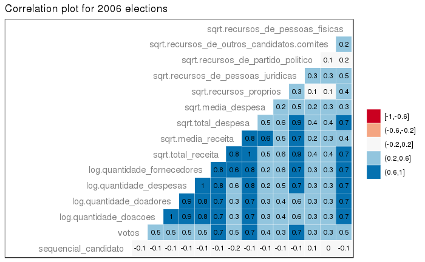

```r
eleicoes_data %>%
  filter(ano == 2006) %>%
  select(-partido,
         -uf,-nome,-id,
         -estado_civil,
         -ocupacao,-ano,
         -total_receita,
         -media_receita,
         -total_despesa,
         -media_despesa,
         -recursos_proprios,
         -cargo,-grau,-sexo,
         -quantidade_doacoes,
         -quantidade_doadores,
         -quantidade_despesas,
         -quantidade_fornecedores,
         -recursos_de_pessoas_fisicas,
         -recursos_de_partido_politico,
         -recursos_de_pessoas_juridicas,
         -recursos_de_outros_candidatos.comites) %>%
  na.omit() %>%
  ggcorr(palette = "RdBu",
         color = "grey50",
         label = TRUE, hjust = 1,
         label_size = 3, size = 4,
         nbreaks = 5, layout.exp = 7) +
  ggtitle("Correlation plot for 2006 elections")
```

- **sequencial_candidato** doesn’t not look meaningful (as expected).
- **total_receita**, **total_despesa** and **recursos_de_pessoas_juridicas** seem very meaningful.

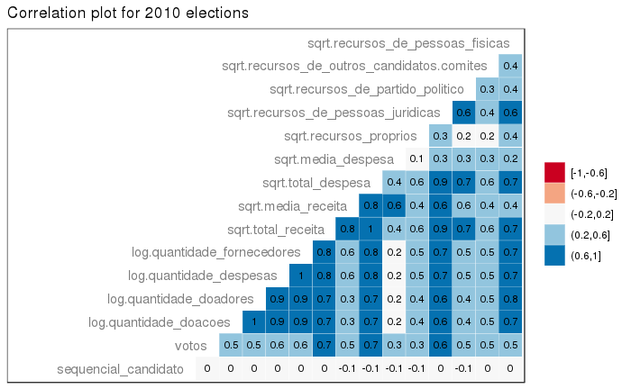

```r
eleicoes_data %>%
  filter(ano == 2010) %>%
  select(-partido,
         -uf,-nome,-id,
         -estado_civil,
         -ocupacao,-ano,
         -total_receita,
         -media_receita,
         -total_despesa,
         -media_despesa,
         -recursos_proprios,
         -cargo,-grau,-sexo,
         -quantidade_doacoes,
         -quantidade_doadores,
         -quantidade_despesas,
         -quantidade_fornecedores,
         -recursos_de_pessoas_fisicas,
         -recursos_de_partido_politico,
         -recursos_de_pessoas_juridicas,
         -recursos_de_outros_candidatos.comites) %>%
  na.omit() %>%
  ggcorr(palette = "RdBu",
         color = "grey50",
         label = TRUE, hjust = 1,
         label_size = 3, size = 4,
         nbreaks = 5, layout.exp = 7) +
  ggtitle("Correlation plot for 2010 elections")
```

- **sequencial_candidato** doesn’t look meaningful (as expected).
- **sqrt.total_receita**, **sqrt.total_despesa** and **sqrt.recursos_de_pessoas_juridicas** seem meaningful.

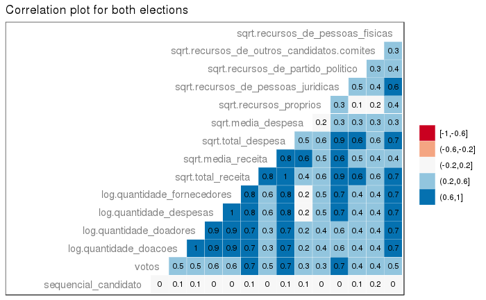

```r
eleicoes_data %>%
  select(-partido,
         -uf,-nome,-id,
         -estado_civil,
         -ocupacao,-ano,
         -total_receita,
         -media_receita,
         -total_despesa,
         -media_despesa,
         -recursos_proprios,
         -cargo,-grau,-sexo,
         -quantidade_doacoes,
         -quantidade_doadores,
         -quantidade_despesas,
         -quantidade_fornecedores,
         -recursos_de_pessoas_fisicas,
         -recursos_de_partido_politico,
         -recursos_de_pessoas_juridicas,
         -recursos_de_outros_candidatos.comites) %>%
  na.omit() %>%
  ggcorr(palette = "RdBu",
         color = "grey50",
         label = TRUE, hjust = 1,
         label_size = 3, size = 4,
         nbreaks = 5, layout.exp = 7) +
  ggtitle("Correlation plot for both elections")
```

- **sequencial_candidato** does’nt look meaningful (as expected).
- **sqrt.total_receita**, **sqrt.total_despesa** and **sqrt.recursos_de_pessoas_juridicas** seem very meaningful.

# Should we use all variables?

#### A multivariate linear regression model made with all variables wouldn’t be feasible

- **cargo** is categorical and renders a one level factor. For this reason we simply can’t use it in our regression.
- **sequencial_candidato** isn’t meaningful at all as the correlogram clearly showed us.
- We have nominal categorical variables such as **uf** that have dozens of levels. A variable like this one demands a *one hot encoding* which would increase exponentialy the number of variables fed to the model and most likely lead to an overfitting.

> For the aforementioned reasons a multivariate linear regression model made with all variables isn’t plausible.

# Model for 2006 elections vs Model for 2010 elections

## Linear Model for 2006 elections

### Split Data for Cross Validation

- Let’s use the $50/25/25$ proportions for the train, validate and test datasets.

```r
scaled_data %>%
   filter(ano == 2006) -> scaled_data_2006
scaled_data_2006 %>%
  sample_n(5)
```

| ano | sequencial_candidato | nome | uf | partido | quantidade_doacoes | quantidade_doadores | total_receita | media_receita | recursos_de_outros_candidatos.comites | recursos_de_pessoas_fisicas | recursos_de_pessoas_juridicas | recursos_proprios | recursos_de_partido_politico | quantidade_despesas | quantidade_fornecedores | total_despesa | media_despesa | cargo | sexo | grau | estado_civil | ocupacao | votos | id | log.quantidade_doacoes | log.quantidade_doadores | log.quantidade_despesas | log.quantidade_fornecedores | sqrt.total_receita | … |
| --- | --- | --- | --- | --- | --- | --- | --- | --- | --- | --- | --- | --- | --- | --- | --- | --- | --- | --- | --- | --- | --- | --- | --- | --- | --- | --- | --- | --- | --- | --- |
| 2006 | -0.9299638 | SERGIO FERREIRA ALVES | RJ | PMDB | -0.22807407 | -0.237215771 | -0.38786576 | -0.3480966 | -0.1835372 | -0.3448548 | -0.3143617 | -0.1716532 | -0.1953397 | -0.3144224 | -0.3194567 | -0.39654068 | -0.12831143 | DEPUTADO FEDERAL | MASCULINO | SUPERIOR INCOMPLETO | CASADO(A) | PROFESSOR DE ENSINO FUNDAMENTAL | 632 | 3081 | -1.67951660 | -1.648297062 | -1.69417565 | -1.67948636 | -0.7112423 | … |
| 2006 | -0.9299638 | MARCELO AUGUSTO DA EIRA CORREA | AM | PSB | -0.01538868 | -0.003510323 | 0.81957298 | 1.0866577 | 3.0822658 | -0.2407637 | 0.4290511 | -0.1716532 | -0.1801923 | -0.2175978 | -0.2091670 | 0.91359502 | 1.79900261 | DEPUTADO FEDERAL | MASCULINO | SUPERIOR COMPLETO | CASADO(A) | FARMACÊUTICO | 92241 | 1248 | 0.73801408 | 0.775766339 | 0.32430035 | 0.35573201 | 1.4553639 | … |
| 2006 | -0.9299638 | ALCEMIR DE JESUS CONTENTE RANIERI | PA | PTB | -0.20255182 | -0.208002590 | -0.38593941 | -0.3621219 | -0.1887710 | -0.3448548 | -0.3143617 | -0.1716532 | -0.1846608 | -0.3071605 | -0.3105143 | -0.39434607 | -0.16007050 | DEPUTADO FEDERAL | MASCULINO | SUPERIOR COMPLETO | SOLTEIRO(A) | PROFESSOR DE ENSINO MÉDIO | 1344 | 506 | -0.65087638 | -0.604309780 | -0.94066883 | -0.90385889 | -0.6682896 | … |
| 2006 | -0.9299638 | REGIS ROBERTO NORI | SP | PHS | -0.15150733 | -0.159313955 | 0.01481505 | 0.8933911 | -0.1887710 | -0.3351892 | -0.3143617 | 1.0203030 | -0.1953397 | -0.2490658 | -0.2449366 | 0.06210425 | 0.81859449 | DEPUTADO FEDERAL | MASCULINO | SUPERIOR COMPLETO | CASADO(A) | ECONOMISTA | 5435 | 3198 | 0.02901783 | 0.006383632 | 0.11701172 | 0.14340873 | 0.5110876 | … |
| 2006 | -0.9299638 | ELIONALDO DE FARO TELES | BA | PT | 0.10371513 | 0.132817855 | -0.29474151 | -0.3123686 | -0.1858753 | 0.0878669 | -0.2721092 | -0.1577217 | -0.1953397 | -0.2611689 | -0.2628214 | -0.30856650 | 0.02812008 | DEPUTADO FEDERAL | MASCULINO | SUPERIOR COMPLETO | CASADO(A) | PROFESSOR DE ENSINO SUPERIOR | 13497 | 1528 | 1.05765805 | 1.110649287 | 0.01009175 | -0.00338328 | -0.1573742 | … |

```r
set.seed(11) # We set the set for reason of reproducibility
scaled_data_2006 %>%
  dplyr::sample_frac(.5) -> train_data_2006
encoding <- build_encoding(dataSet = train_data_2006,
                           cols = c("uf","sexo","grau",
                                    "partido","estado_civil"),
                           verbose = F)
train_data_2006 <- one_hot_encoder(dataSet = train_data_2006,
                           encoding = encoding,
                           drop = TRUE,
                           verbose = F)
cat("#### Train Data ",
    "\n##### Observations: ",nrow(train_data_2006),
    "\n##### Variables: ",ncol(train_data_2006))
```

#### Train Data

##### Observations: 1718

##### Variables: 102

```r
set.seed(11) # We set the set for reason of reproducibility
dplyr::anti_join(scaled_data_2006,
                 train_data_2006,
                 by = 'id') -> intermediate_data
intermediate_data %>%
  dplyr::sample_frac(.5) -> test_data_2006
test_data_2006 <- one_hot_encoder(dataSet = test_data_2006,
                           encoding = encoding,
                           drop = TRUE,
                           verbose = F)
cat("#### Test Data ",
    "\n##### Observations: ",nrow(test_data_2006),
    "\n##### Variables: ",ncol(test_data_2006))
```

#### Test Data

##### Observations: 859

##### Variables: 102

```r
set.seed(11) # We set the set for reason of reproducibility
dplyr::anti_join(intermediate_data,
                 test_data_2006,
                 by = 'id') -> validate_data_2006
validate_data_2006 <- one_hot_encoder(dataSet = validate_data_2006,
                           encoding = encoding,
                           drop = TRUE,
                           verbose = F)
rm(intermediate_data)
cat("#### Validate Data ",
    "\n##### Observations: ",nrow(validate_data_2006),
    "\n##### Variables: ",ncol(validate_data_2006))
```

#### Validate Data

##### Observations: 859

##### Variables: 102

### Train the model

```r
mod_2006 <- lm(votos ~ log.quantidade_fornecedores * partido.PSDB + sqrt.media_despesa * partido.PMDB +
                  sqrt.total_receita * sqrt.total_despesa + uf.SP * estado.civil.CASADO.A. +
                  uf.RJ * sqrt.total_despesa + sqrt.total_receita * `grau.SUPERIOR COMPLETO`,
          data = train_data_2006)
broom::glance(mod_2006)
```

|  | r.squared | adj.r.squared | sigma | statistic | p.value | df | logLik | AIC | BIC | deviance | df.residual |
| --- | --- | --- | --- | --- | --- | --- | --- | --- | --- | --- | --- |
| 1 | 0.5210543 | 0.5165493 | 31581.39 | 115.6594 | 8.40374e-258 | 17 | -20228.23 | 40492.46 | 40590.54 | 1.696551e+12 | 1701 |

- As these quality metrics come from training they aren’t that meaningful:
  - A decent $R^2$ and $adjusted \thinspace R^2$ around $0.5$.
  - The $F \thinspace statistic$ (statistic) is way bigger than 1 (a good sign).

```r
broom::tidy(mod_2006,
            conf.int = TRUE,
            conf.level = 0.95)
```

| term | estimate | std.error | statistic | p.value | conf.low | conf.high |
| --- | --- | --- | --- | --- | --- | --- |
| (Intercept) | 33433.5070 | 2269.665 | 14.73058859 | 2.575800e-46 | 28981.877 | 37885.1369 |
| log.quantidade_fornecedores | -12327.0448 | 2031.584 | -6.06770068 | 1.595920e-09 | -16311.712 | -8342.3777 |
| partido.PSDB | -3865.6660 | 3445.214 | -1.12203936 | 2.620041e-01 | -10622.970 | 2891.6380 |
| sqrt.media_despesa | -2452.5000 | 1688.993 | -1.45204843 | 1.466726e-01 | -5765.223 | 860.2231 |
| partido.PMDB | -981.1849 | 2772.843 | -0.35385522 | 7.234912e-01 | -6419.727 | 4457.3569 |
| sqrt.total_receita | -14239.3994 | 10973.191 | -1.29765349 | 1.945824e-01 | -35761.773 | 7282.9738 |
| sqrt.total_despesa | 75440.2624 | 11734.076 | 6.42916084 | 1.662415e-10 | 52425.520 | 98455.0052 |
| uf.SP | 4022.2539 | 3231.591 | 1.24466667 | 2.134258e-01 | -2316.059 | 10360.5665 |
| estado.civil.CASADO.A. | 1078.5312 | 1845.910 | 0.58428143 | 5.591085e-01 | -2541.963 | 4699.0255 |
| uf.RJ | -237.3764 | 2660.547 | -0.08922089 | 9.289169e-01 | -5455.667 | 4980.9138 |

[output cut: 7 more lines]

## Linear Model for 2010 elections

### Split Data for Cross Validation

- Let’s use the $50/25/25$ proportions for the train, validate and test datasets

```r
scaled_data %>%
  filter(ano == 2010) -> scaled_data_2010
scaled_data_2010 %>%
  sample_n(5)
```

| ano | sequencial_candidato | nome | uf | partido | quantidade_doacoes | quantidade_doadores | total_receita | media_receita | recursos_de_outros_candidatos.comites | recursos_de_pessoas_fisicas | recursos_de_pessoas_juridicas | recursos_proprios | recursos_de_partido_politico | quantidade_despesas | quantidade_fornecedores | total_despesa | media_despesa | cargo | sexo | grau | estado_civil | ocupacao | votos | id | log.quantidade_doacoes | log.quantidade_doadores | log.quantidade_despesas | log.quantidade_fornecedores | sqrt.total_receita | … |
| --- | --- | --- | --- | --- | --- | --- | --- | --- | --- | --- | --- | --- | --- | --- | --- | --- | --- | --- | --- | --- | --- | --- | --- | --- | --- | --- | --- | --- | --- | --- |
| 2010 | 0.3820020 | FERNANDO EUSTAQUIO PEIXOTO DE MAGALHAES | MG | PRTB | -0.1685222 | -0.1885271 | -0.3733061 | -0.3245731 | -0.1887710 | -0.33741975 | -0.31436171 | -0.12820018 | -0.1953397 | -0.28295440 | -0.28666783 | -0.38225017 | -0.14611420 | DEPUTADO FEDERAL | MASCULINO | SUPERIOR COMPLETO | CASADO(A) | VETERINÁRIO | 618 | 4557 | -0.1365563 | -0.2989631 | -0.2597417 | -0.2891887 | -0.5268770 | … |
| 2010 | -0.8290435 | EDSON FIRMINO DE PAULA | AC | PSDB | -0.2110592 | -0.2177403 | -0.3849762 | -0.3435992 | -0.1860114 | -0.32254959 | -0.31436171 | -0.17132152 | -0.1953397 | -0.30958115 | -0.31349505 | -0.39324876 | -0.11812762 | DEPUTADO FEDERAL | MASCULINO | SUPERIOR INCOMPLETO | CASADO(A) | OPERADOR DE EQUIPAMENTO DE RÁDIO, TELEVISÃO, SOM E CINEMA | 312 | 3439 | -0.8643385 | -0.8209567 | -1.0970356 | -1.0648161 | -0.6520040 | … |
| 2010 | 0.9875247 | MARCELO VIVIANI GONCALVES | RJ | PDT | 0.9459493 | 0.6197042 | 0.1598459 | -0.2619499 | 0.1226833 | 1.27361366 | -0.02193585 | 0.02736835 | -0.1953397 | 0.07771705 | -0.05416521 | 0.13525460 | -0.01062438 | DEPUTADO FEDERAL | MASCULINO | ENSINO MÉDIO COMPLETO | CASADO(A) | COMERCIANTE | 80862 | 5498 | 1.9818980 | 1.7319946 | 1.0744828 | 0.8381434 | 0.7255830 | … |
| 2010 | -0.7281230 | ELIAS BARROS DIAS | AL | PR | -0.2280741 | -0.2372158 | -0.3846805 | -0.2471122 | -0.1700053 | -0.34485483 | -0.31436171 | -0.17165322 | -0.1953397 | -0.31442238 | -0.31945666 | -0.39291184 | 0.10035870 | DEPUTADO FEDERAL | MASCULINO | SUPERIOR COMPLETO | CASADO(A) | ADVOGADO | 1128 | 3493 | -1.6795166 | -1.6482971 | -1.6941756 | -1.6794864 | -0.6473963 | … |
| 2010 | -0.4253617 | SEGIO LUIS LACERDA BRITO | BA | PSC | -0.1004628 | -0.1008876 | -0.1122014 | 0.1615072 | -0.1110469 | -0.07421787 | -0.30405718 | 0.12462023 | 0.1833448 | -0.18612985 | -0.19128214 | -0.09572869 | 0.13591117 | DEPUTADO FEDERAL | MASCULINO | SUPERIOR COMPLETO | CASADO(A) | DEPUTADO | 71889 | 3698 | 0.3777638 | 0.3910750 | 0.4739979 | 0.4377562 | 0.2885187 | … |

```r
set.seed(11) # We set the set for reason of reproducibility
scaled_data_2010 %>%
  dplyr::sample_frac(.5) -> train_data_2010
encoding <- build_encoding(dataSet = train_data_2010,
                           cols = c("uf","sexo","grau",
                                    "partido","estado_civil"),
                           verbose = F)
train_data_2010 <- one_hot_encoder(dataSet = train_data_2010,
                           encoding = encoding,
                           drop = TRUE,
                           verbose = F)
cat("#### Train Data ",
    "\n##### Observations: ",nrow(train_data_2010),
    "\n##### Variables: ",ncol(train_data_2010))
```

#### Train Data

##### Observations: 2020

##### Variables: 101

```r
set.seed(11) # We set the set for reason of reproducibility
dplyr::anti_join(scaled_data_2010,
                 train_data_2010,
                 by = 'id') -> intermediate_data
intermediate_data %>%
  dplyr::sample_frac(.5) -> test_data_2010
test_data_2010 <- one_hot_encoder(dataSet = test_data_2010,
                           encoding = encoding,
                           drop = TRUE,
                           verbose = F)
cat("#### Test Data ",
    "\n##### Observations: ",nrow(test_data_2010),
    "\n##### Variables: ",ncol(test_data_2010))
```

#### Test Data

##### Observations: 1010

##### Variables: 101

```r
set.seed(11) # We set the set for reason of reproducibility
dplyr::anti_join(intermediate_data,
                 test_data_2010,
                 by = 'id') -> validate_data_2010
validate_data_2010 <- one_hot_encoder(dataSet = validate_data_2010,
                           encoding = encoding,
                           drop = TRUE,
                           verbose = F)
rm(intermediate_data)
cat("#### Validate Data ",
    "\n##### Observations: ",nrow(validate_data_2010),
    "\n##### Variables: ",ncol(validate_data_2010))
```

#### Validate Data

##### Observations: 1010

##### Variables: 101

## Train the model

```r
mod_2010 <- lm(votos ~ log.quantidade_fornecedores * partido.PSDB + sqrt.media_despesa * partido.PMDB +
                  sqrt.total_receita * sqrt.total_despesa + uf.SP * estado.civil.CASADO.A. +
                  uf.RJ * sqrt.total_despesa + sqrt.total_receita * `grau.SUPERIOR COMPLETO`,
          data = train_data_2010)
broom::glance(mod_2010)
```

|  | r.squared | adj.r.squared | sigma | statistic | p.value | df | logLik | AIC | BIC | deviance | df.residual |
| --- | --- | --- | --- | --- | --- | --- | --- | --- | --- | --- | --- |
| 1 | 0.4497484 | 0.445353 | 41279.81 | 102.3221 | 1.150521e-245 | 17 | -24326.54 | 48689.08 | 48790.08 | 3.413158e+12 | 2003 |

- As the quality metric come from training they aren’t that meaningful
  - The $R^2$ and $adjusted \thinspace R^2$ around $0.45$ are borderline disappointing.
  - The $F \thinspace statistic$ (statistic) is way bigger than 1 (a good sign).

```r
broom::tidy(mod_2010,
            conf.int = TRUE,
            conf.level = 0.95)
```

| term | estimate | std.error | statistic | p.value | conf.low | conf.high |
| --- | --- | --- | --- | --- | --- | --- |
| (Intercept) | 27781.6353 | 2334.4703 | 11.9006163 | 1.328272e-31 | 23203.391 | 32359.880 |
| log.quantidade_fornecedores | -14527.7580 | 2494.3079 | -5.8243644 | 6.663022e-09 | -19419.468 | -9636.048 |
| partido.PSDB | -4555.4579 | 4212.3371 | -1.0814562 | 2.796244e-01 | -12816.479 | 3705.563 |
| sqrt.media_despesa | -5917.2112 | 1496.5152 | -3.9539934 | 7.952796e-05 | -8852.101 | -2982.322 |
| partido.PMDB | -1023.8472 | 3664.1583 | -0.2794222 | 7.799497e-01 | -8209.808 | 6162.113 |
| sqrt.total_receita | 29282.5319 | 9996.9572 | 2.9291445 | 3.437375e-03 | 9677.009 | 48888.055 |
| sqrt.total_despesa | 35640.6358 | 10103.0512 | 3.5277101 | 4.286118e-04 | 15827.047 | 55454.225 |
| uf.SP | -3309.6316 | 3587.6656 | -0.9225028 | 3.563775e-01 | -10345.578 | 3726.315 |
| estado.civil.CASADO.A. | -811.3875 | 2186.3357 | -0.3711175 | 7.105892e-01 | -5099.118 | 3476.343 |
| uf.RJ | -310.1600 | 2712.5040 | -0.1143445 | 9.089762e-01 | -5629.785 | 5009.465 |

[output cut: 7 more lines]

# Evaluating Models

##### We shall keep out the *Intercept* from our p.value and coefficient analysis as its analysis isn’t as meaningful as that of other predictors.

## P Value

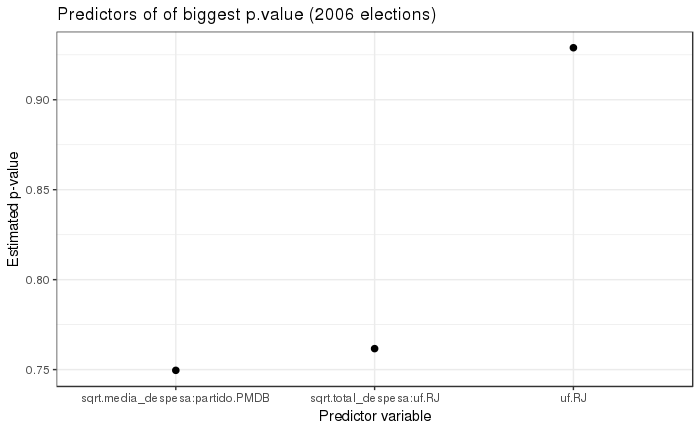

```r
broom::tidy(mod_2006,
     conf.int = TRUE,
     conf.level = 0.95,
     sep=":") %>%
  arrange(desc(p.value)) %>%
  slice(1:3) %>%
  ggplot(aes(reorder(term,p.value), p.value)) +
  geom_point(size = 2) +
  labs(x = "Predictor variable",
       y = "Estimated p-value",
       title="Predictors of of biggest p.value (2006 elections)")
```

- The predictors created out of the encoding of the nominal categorical variables **uf** and **partido** didn’t perform well.
- Unexpectedly **sqrt.total_despesa** didn’t perform so well in terms of $p-value$, probably due to the interaction with the underperforming variable **uf**.
- Unexpectedly **sqrt.media_despesa** didn’t perform so well in terms of $p-value$, probably due to the interaction with the underperforming variable **partido**.

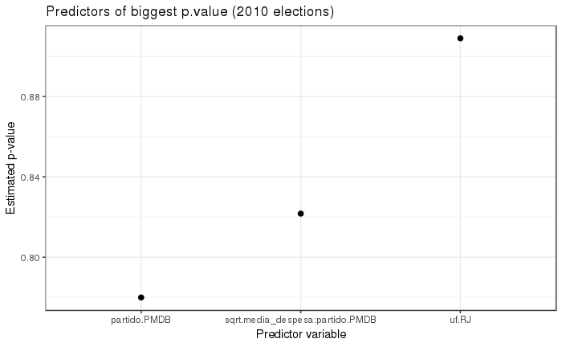

```r
broom::tidy(mod_2010,
     conf.int = TRUE,
     conf.level = 0.95,
     sep=":") %>%
  arrange(desc(p.value)) %>%
  slice(1:3) %>%
  ggplot(aes(reorder(term,p.value), p.value)) +
  geom_point(size = 2) +
  labs(x = "Predictor variable",
       y = "Estimated p-value",
       title="Predictors of biggest p.value (2010 elections)")
```

- The predictors created out of the encoding of the nominal categorical variables **partido** and **uf** didn’t perform well.
- The predictor **sqrt.media_despesa** didn’t perform so well in terms of $p-value$, probably due to the interaction with the underperforming variable **partido**.

> On both models we can see that predictors related to **partido** perform poorly. Also we could see the sizable appearance of categorical variable among underperformer predictors.

##### P Value isn’t as effective in pointing out who are the most meaningful predictors as it’s in pointing which are the least meaningful.

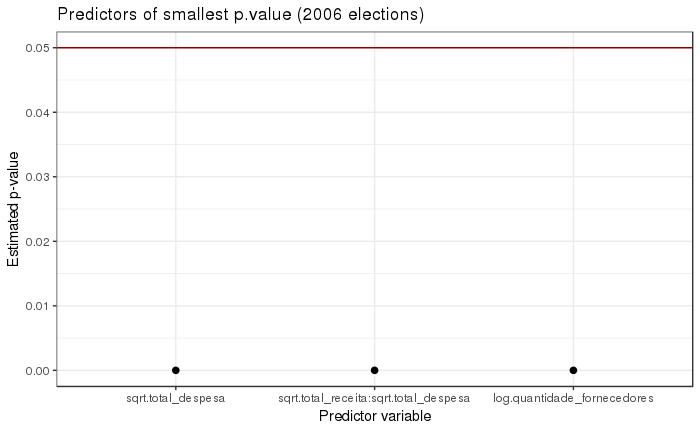

```r
broom::tidy(mod_2006,
     conf.int = TRUE,
     conf.level = 0.95,
     sep=":") %>%
  filter(term != "(Intercept)") %>%
  arrange(p.value) %>%
  slice(1:3) %>%
  ggplot(aes(reorder(term,p.value), p.value)) +
  geom_hline(yintercept = 0.05, colour = "darkred") +
  geom_point(size = 2) +
  labs(x = "Predictor variable",
       y = "Estimated p-value",
       title="Predictors of smallest p.value (2006 elections)")
```

- We can see the presence of different combinations of the predictors **sqrt.total_receita** and **sqrt.total_despesa** as predictors with good pvalues. This corroborates what the *correlogram* suggested.
- We also have **log.quantidade_fornecedores** with positive results.

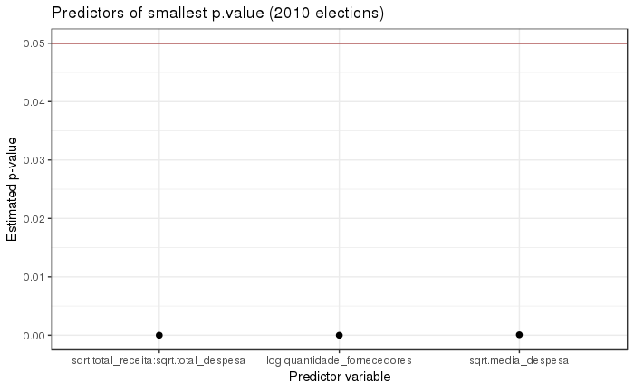

```r
broom::tidy(mod_2010,
     conf.int = TRUE,
     conf.level = 0.95,
     sep=":") %>%
  filter(term != "(Intercept)") %>%
  arrange(p.value) %>%
  slice(1:3) %>%
  ggplot(aes(reorder(term,p.value), p.value)) +
  geom_hline(yintercept = 0.05, colour = "darkred") +
  geom_point(size = 2) +
  labs(x = "Predictor variable",
       y = "Estimated p-value",
       title="Predictors of smallest p.value (2010 elections)")
```

- We can see the presence of different combinations of the predictors **sqrt.total_receita** and **sqrt.total_despesa** as predictors with good pvalues. This corroborates what the *correlogram* suggested.
- We also have **log.quantidade_fornecedores** and **sqrt.media_despesa** with positive results.

> On both models different combinations of the predictors **sqrt.total_receita** and **sqrt.total_despesa** were clearly the best predictors (those that could explain the votes the most).

## Coefficients

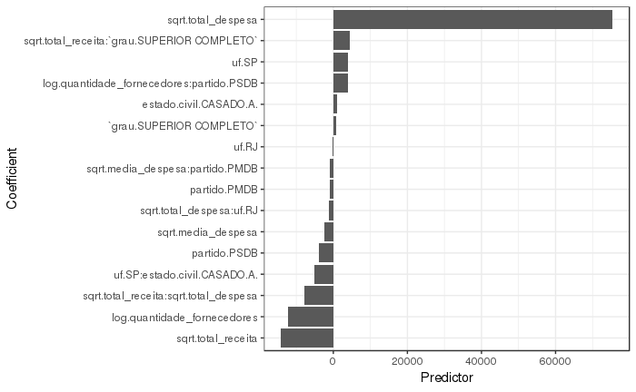

```r
broom::tidy(mod_2006,
     conf.int = TRUE,
     conf.level = 0.95,
     sep=":") %>%
  filter(term != "(Intercept)") %>%
  ggplot(aes(reorder(term, estimate),
             estimate )) +
  geom_bar(stat = "identity") +
  coord_flip() +
  labs(x="Coefficient",y="Predictor")
```

- Results regarding coefficients corroborate what we saw in the predictors’ $p.value$.
  - **uf** and **partido** don’t seem meaningful (smallest coefficients).
  - **sqrt.total_receita**, **log.quantidade_fornecedores** and specially **sqrt.total_despesa** seem particularly meaningful (biggest coefficients).

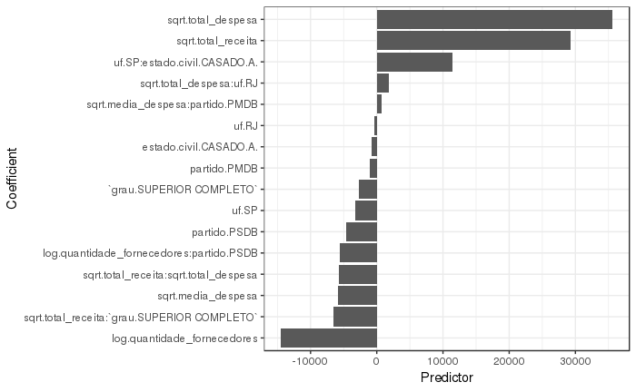

```r
broom::tidy(mod_2010,
     conf.int = TRUE,
     conf.level = 0.95,
     sep=":") %>%
  filter(term != "(Intercept)") %>%
  ggplot(aes(reorder(term, estimate),
             estimate )) +
  geom_bar(stat = "identity") +
  coord_flip() +
  labs(x="Coefficient",y="Predictor")
```

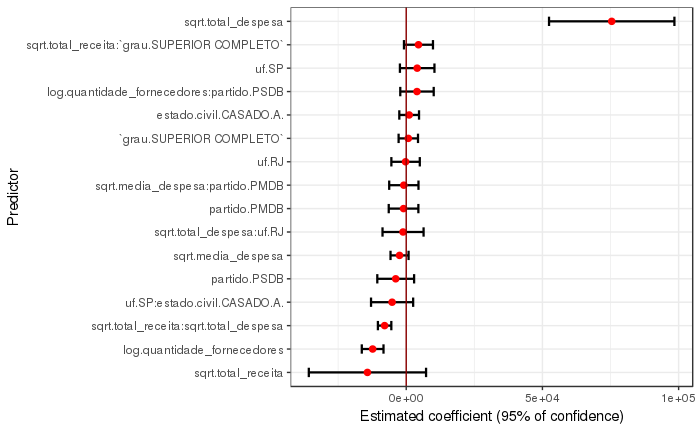

```r
broom::tidy(mod_2006,
     conf.int = TRUE,
     conf.level = 0.95)  %>%
  filter(term != "(Intercept)") %>%
  ggplot(aes(reorder(term, estimate),
             estimate, ymin = conf.low,
             ymax = conf.high)) +
  geom_errorbar(size = 0.8, width= 0.4) +
  geom_point(color = "red", size = 2) +
  geom_hline(yintercept = 0, colour = "darkred") +
  labs(x = "Predictor",
       y = "Estimated coefficient (95% of confidence)") +
  coord_flip()
```

- The only predictors that seem statiscally significant at a level of confidence of $95\%$ are **sqrt.total_despesa**, **log.quantidade_fornecedores** and the interaction between **sqrt.total_despesa** and **sqrt.total_receita**

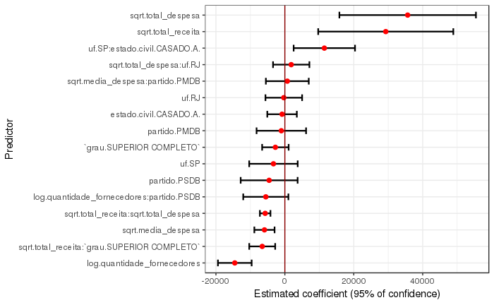

```r
broom::tidy(mod_2010,
     conf.int = TRUE,
     conf.level = 0.95)  %>%
  filter(term != "(Intercept)") %>%
  ggplot(aes(reorder(term, estimate),
             estimate, ymin = conf.low,
             ymax = conf.high)) +
  geom_errorbar(size = 0.8, width= 0.4) +
  geom_point(color = "red", size = 2) +
  geom_hline(yintercept = 0, colour = "darkred") +
  labs(x = "Predictor",
       y = "Estimated coefficient (95% of confidence)") +
  coord_flip()
```

- In the model for the 2010 elections at a level of confidence of $95\%$ we have evidence of more statiscally significant predictors, among which we still have **sqrt.total_despesa**, **log.quantidade_fornecedores** and now also **sqrt.total_receita** (among others).

## Residue Analysis

##### Resorting to thumb rules regarding **Cook’s Distance** we’ll use $D_i > 1$ as a cutoff for highly influential points/outliers

### Residual vs Fitted

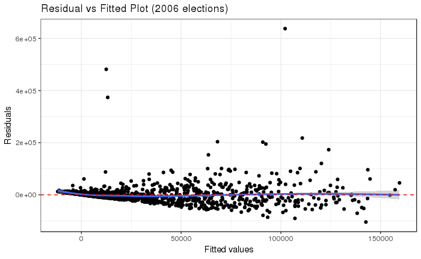

```r
mod_2006 %>%
  ggplot(aes(.fitted, .resid)) +
  geom_point() +
  stat_smooth(method="loess") +
  geom_hline(col="red",
             yintercept=0,
             linetype="dashed") +
  labs(y="Residuals",
       x="Fitted values",
       title="Residual vs Fitted Plot (2006 elections)")
```

- There’s indication, although not strong, of a pattern in the *residual vs fitted*, this is a bad sign for the analyzed model.

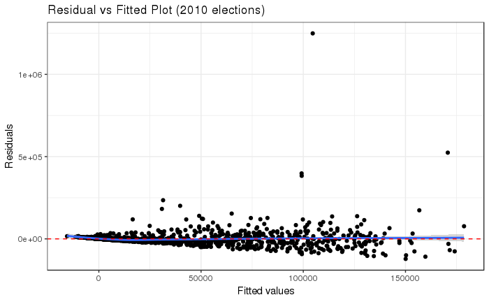

```r
mod_2010 %>%
  ggplot(aes(.fitted, .resid)) +
  geom_point() +
  stat_smooth(method="loess") +
  geom_hline(col="red",
             yintercept=0,
             linetype="dashed") +
  labs(y="Residuals",
       x="Fitted values",
       title="Residual vs Fitted Plot (2010 elections)")
```

- Here we can see rather equally spread residuals around a horizontal line (could be better) without distinct patterns. A good sign for the model.

### Normal Q-Q

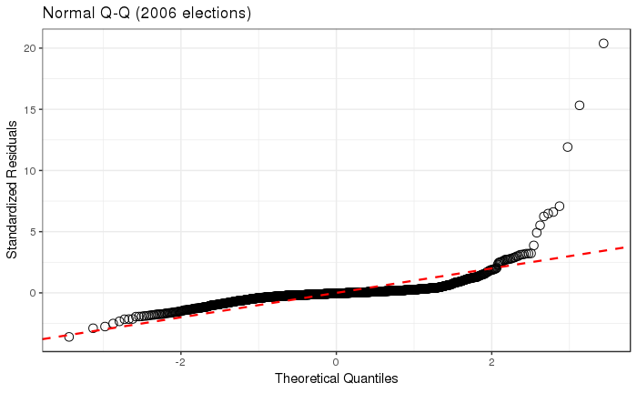

```r
mod_2006 %>%
  ggplot(aes(sample=rstandard(.))) +
  stat_qq(na.rm = TRUE,
          shape=1,size=3) +      # open circles
  labs(title="Normal Q-Q (2006 elections)",        # plot title
  x="Theoretical Quantiles",      # x-axis label
  y="Standardized Residuals") +   # y-axis label +
  geom_abline(color = "red",
              size = 0.8,
              linetype="dashed")  # dashed reference line
```

- Our residuals somewhat deviate from a normal distribution. As we have a *relatively* mild deviation we have a negative yet mild symptom.

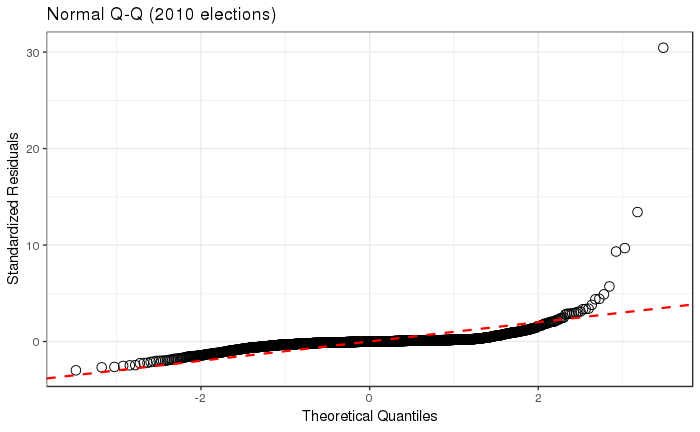

```r
mod_2010 %>%
  ggplot(aes(sample=rstandard(.))) +
  stat_qq(na.rm = TRUE,
          shape=1,size=3) +      # open circles
  labs(title="Normal Q-Q (2010 elections)",        # plot title
  x="Theoretical Quantiles",      # x-axis label
  y="Standardized Residuals") +   # y-axis label +
  geom_abline(color = "red",
              size = 0.8,
              linetype="dashed")  # dashed reference line
```

### Scale-Location

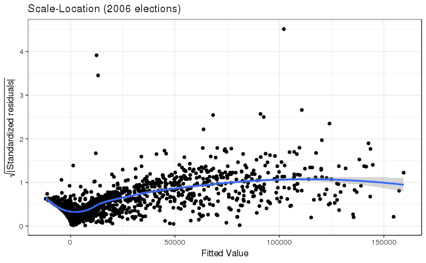

```r
mod_2006 %>%
  ggplot(aes(.fitted,
             sqrt(abs(.stdresid)))) +
  geom_point(na.rm=TRUE) +
  stat_smooth(method="loess",
              na.rm = TRUE) +
  labs(title = "Scale-Location (2006 elections)",
       x= "Fitted Value",
       y = expression(sqrt("|Standardized residuals|")))
```

- The residuals are not equally spread. Our model has violated the assumption of $homoscedasticity$ (equal variance) which is a bad sign.
  - The degree of the violation isn’t so extense, as from around the 50000th fitted value onward the residuals seem very equally spread.

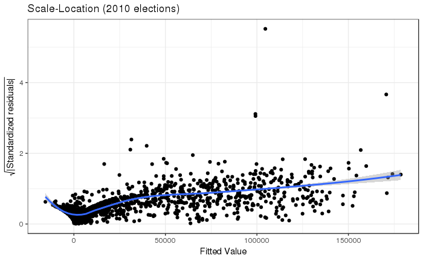

```r
mod_2010 %>%
  ggplot(aes(.fitted,
             sqrt(abs(.stdresid)))) +
  geom_point(na.rm=TRUE) +
  stat_smooth(method="loess",
              na.rm = TRUE) +
  labs(title = "Scale-Location (2010 elections)",
       x= "Fitted Value",
       y = expression(sqrt("|Standardized residuals|")))
```

- Here we see a scenario similar to the one we just witnessed on the previous model.

### Residual vs Leverage Plot

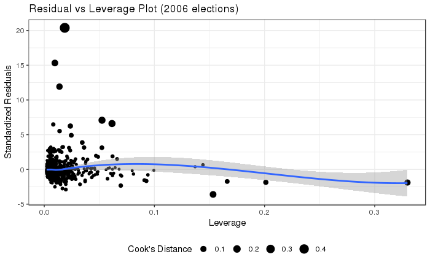

```r
mod_2006 %>%
  ggplot(aes(.hat, .stdresid)) +
  geom_point(aes(size=.cooksd), na.rm=TRUE) +
  stat_smooth(method="loess", na.rm=TRUE) +
  xlab("Leverage")+ylab("Standardized Residuals") +
  ggtitle("Residual vs Leverage Plot (2006 elections)") +
  scale_size_continuous("Cook's Distance", range=c(1,5)) +
  theme(legend.position="bottom")
```

- We can see no outliers that would drastically change the results of our model.

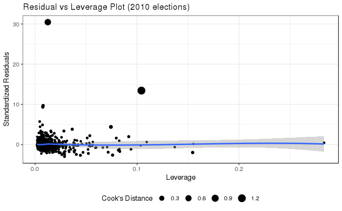

```r
mod_2010 %>%
  ggplot(aes(.hat, .stdresid)) +
  geom_point(aes(size=.cooksd), na.rm=TRUE) +
  stat_smooth(method="loess", na.rm=TRUE) +
  xlab("Leverage")+ylab("Standardized Residuals") +
  ggtitle("Residual vs Leverage Plot (2010 elections)") +
  scale_size_continuous("Cook's Distance", range=c(1,5)) +
  theme(legend.position="bottom")
```

- Here we have evidence of a outlier that would drastically change the results of our model: $D_i = 1.2$